# FordGoBike Data Exploration

## by Islam Soliman

## Investigation Overview

> In this investigation of the Ford GoBike System, I performed the analysis against the most common customer behaviors and characteristics, specifically how user type, and time impacts the usage of the bike share system.

## Dataset Overview

> Ford GoBike is the San Francisco Bay Area's bike share system. The Bike Share was introduced in 2013 as a pilot program for the region, with 700 bikes covering 70 stations across San Francisco and San Jose. It is now called **Baywheels**.  
> Baywheels, like other bike share systems, consists of a fleet of specially designed, sturdy and durable bikes that are locked into a network of docking stations throughout the city. The bikes can be unlocked from one station and returned to any other station in the system, making them ideal for one-way trips. People use bike share to commute to work or school, run errands, get to appointments or social engagements and more. It's a fun, convenient and affordable way to get around.  
> The bikes are available for use 24/7 all year round, and riders have access to all bikes in the network when they become a member or purchase a pass.

## Ford GoBike Usage Per Hour

The bikes were mostly used during the morning hours of `8-9AM`, and at the afternoon hours of `4-6PM`, which is a typical workday in the United States.  
This furthers the suggestion that the bikes are being used primarily for commuters.

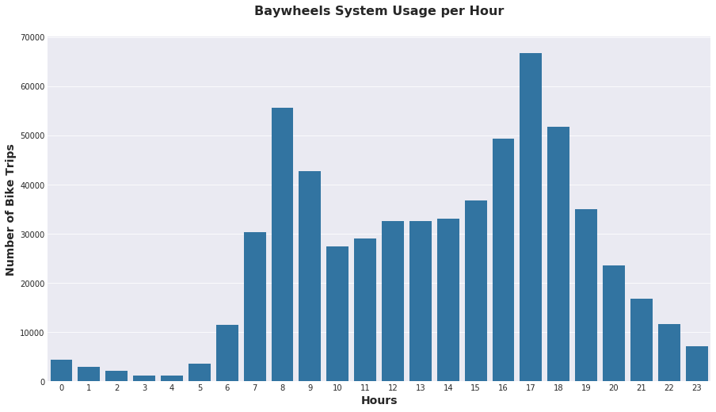

## Average Trip Time in Minutes

The **`average trip time`** is about `10 minutes`, with **`75% of trips`** duration being under `15 minutes`. Looking at the histogram, **`most rides`** fall in between the `3 - 13 minute range`.  
This suggests riders are using the bikes for short distances.

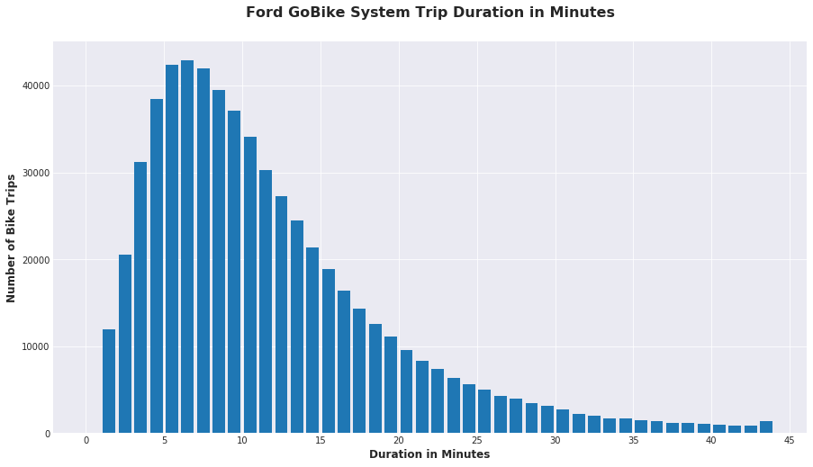

### Ford GoBike System - Customers Vs Subscribers

The majority of users of the Baywheels Bike System are `Subscribers 61.3%` i.e. customers who subscribe to the monthly membership. While `customers` who pays by trip are `38.7%`.

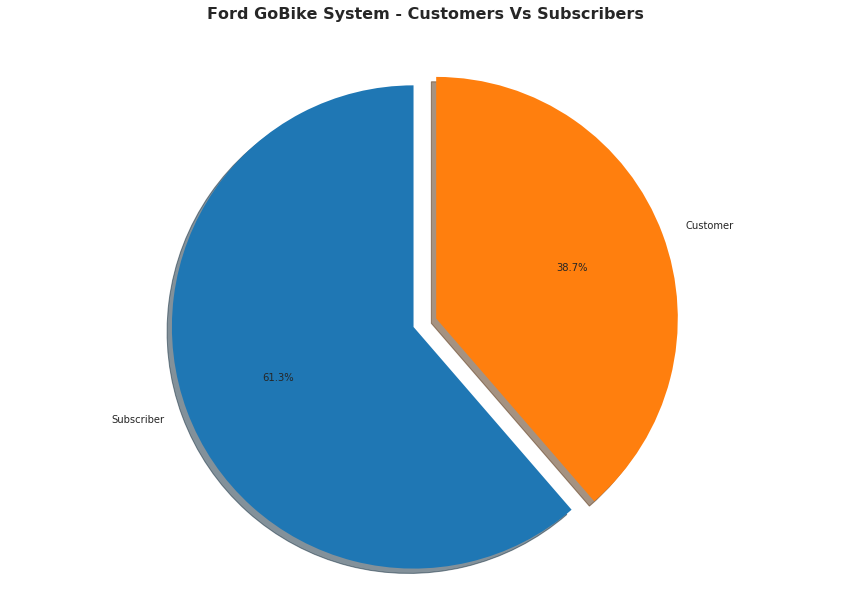

## Ford GoBike System Trends by User Type

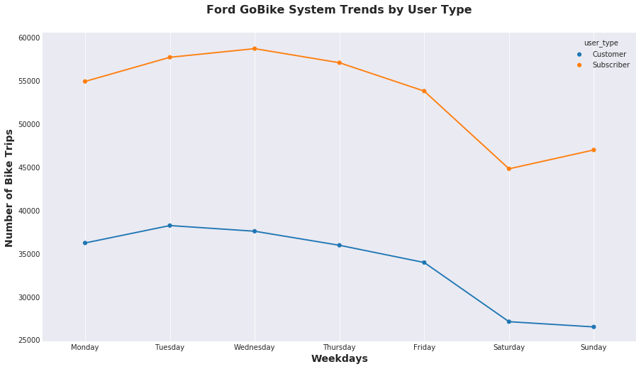

### Ford GoBike System - Customers vs. Subscribers Ride Duration in Minutes

This plot shows the ride duration spread in minutes.  
Both `customers and subscribers` have used the Bike sharing system almost *`equal`* in duration, less than or equal to 60 minutes.

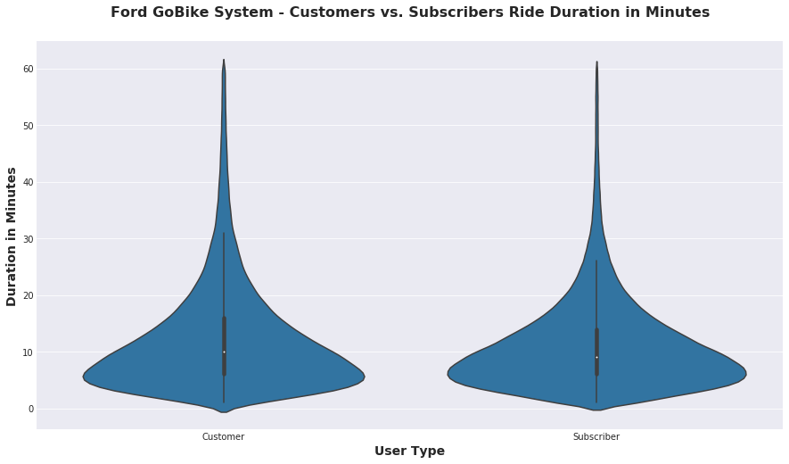